# Analise de Coorte

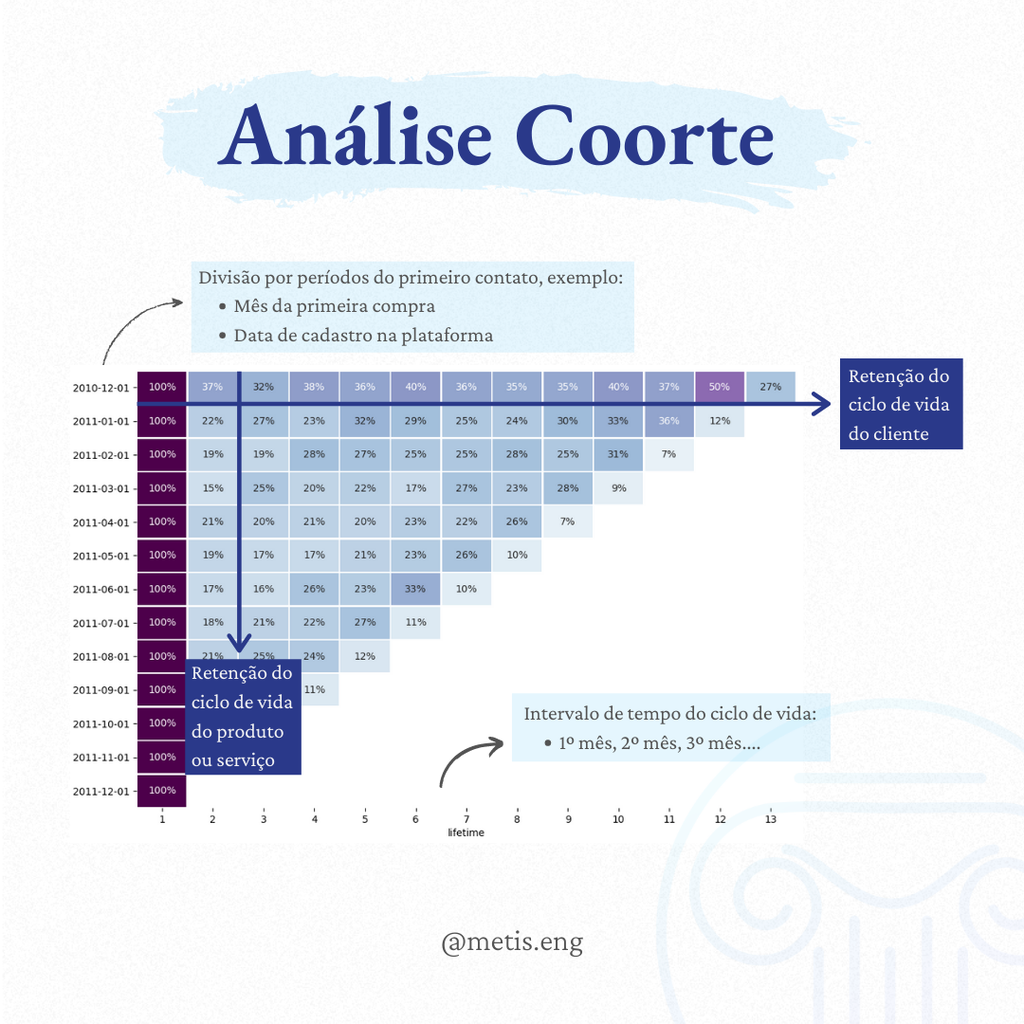

Empresas que enfrentam incertezas do mercado ou mudanças frequentes em seus produtos, serviços e processos precisar de métricas específicas que avaliem os diferentes momentos do ciclo de vida. E uma destas ferramentas é a **Análise de Coorte** (ou Análise Cohort).

Presente em muitas plataformas como o Google Analytics, o princípio por trás da métrica é de que *clientes de períodos diferentes vão ter experiências diferentes*, por mais sutis que aparentam ser.

Por definição, um coorte é um grupo de indivíduos que compartilham a mesma característica, e a métrica permite avaliar o comportamento do coorte durante o tempo e compará-lo com outros coortes. Em uma de suas aplicações no setor de marketing/comercial, a análise divide os clientes de acordo com o período de aquisição do produto ou serviço e o seu ciclo de vida em um intervalo definido.

Assim, é possível analisar a retenção dos clientes durante o ciclo de vida do produto, e mais importante: durante o ciclo de vida do cliente, agrupado de acordo com o primeiro contato. Tudo isso de forma visual e intuitiva.

Desta forma, as métricas ficam bastante granulares e permitem avaliar com precisão o impacto das alterações, investimentos e campanhas, por exemplo.

Além da análise temporal, os coortes permitem dividir em outros grupos como:

- Produto ou plano adquirido;
- Quantidade ou valor gasto;

E quaisquer agrupamentos que possam representar diferentes comportamentos ou necessidades dos clientes.

# Roteiro de Análise Coorte - Tratamento e visualização de dados

Para este exemplo será utilizado um conjunto de dados do [repositório da UCI](https://archive.ics.uci.edu/).

Os dados estão em uma planilha do excel (.xlsx) e representam vendas de uma loja on-line no Reino Unido. As colunas presentes no dataset são:

- `Número do pedido`;
- Código do produto;
- Descrição do produto;
- Quantidade;
- `Data do pedido`;
- Preço unitário;
- `ID do cliente`;
- País.

Contudo, para elaboração da análise de coorte só serão utilizadas as 3 colunas em destaque.

**Pacotes e bibliotecas Python utilizadas**

```python
import numpy as np
import pandas as pd
import datetime as dt
import matplotlib.pyplot as plt
import seaborn as sns
```

**Leitura dos dados**

```python
df = pd.read_excel('Online Retail.xlsx')
```

```python
df.head(5)
```

|  | InvoiceNo | StockCode | Description | Quantity | InvoiceDate | UnitPrice | CustomerID | Country |
| --- | --- | --- | --- | --- | --- | --- | --- | --- |
| 0 | 536365 | 85123A | WHITE HANGING HEART T-LIGHT HOLDER | 6 | 2010-12-01 08:26:00 | 2.55 | 17850.0 | United Kingdom |
| 1 | 536365 | 71053 | WHITE METAL LANTERN | 6 | 2010-12-01 08:26:00 | 3.39 | 17850.0 | United Kingdom |
| 2 | 536365 | 84406B | CREAM CUPID HEARTS COAT HANGER | 8 | 2010-12-01 08:26:00 | 2.75 | 17850.0 | United Kingdom |
| 3 | 536365 | 84029G | KNITTED UNION FLAG HOT WATER BOTTLE | 6 | 2010-12-01 08:26:00 | 3.39 | 17850.0 | United Kingdom |
| 4 | 536365 | 84029E | RED WOOLLY HOTTIE WHITE HEART. | 6 | 2010-12-01 08:26:00 | 3.39 | 17850.0 | United Kingdom |

## Tratamento dos dados

#### **Contagem de linhas e identificação do tipo**

```python
df.columns = ['PedidoNum', 'ProdutoCod', 'ProdutoDesc', 'Qtd', 'PedidoData', 'PrecoUnit', 'ClienteID', 'Pais']
df.info()
```

```
<class 'pandas.core.frame.DataFrame'>
RangeIndex: 541909 entries, 0 to 541908
Data columns (total 8 columns):
 #   Column       Non-Null Count   Dtype
---  ------       --------------   -----
 0   PedidoNum    541909 non-null  object
 1   ProdutoCod   541909 non-null  object
 2   ProdutoDesc  540455 non-null  object
 3   Qtd          541909 non-null  int64
 4   PedidoData   541909 non-null  datetime64[ns]
 5   PrecoUnit    541909 non-null  float64
 6   ClienteID    406829 non-null  float64
 7   Pais         541909 non-null  object
dtypes: datetime64[ns](1), float64(2), int64(1), object(4)
memory usage: 33.1+ MB
```

#### **Limpeza dos dados**

Na descrição do conjunto de dados é informado que os pedidos que se iniciam com `C` representam `cancelamentos`.

Portanto, estes registros serão eliminados do conjunto.

```python
df= df[df['PedidoNum'].str[0] != 'C']
```

**Contabilizando linhas com valores não preenchidos**

```python
df.isnull().sum()
```

```
PedidoNum           0
ProdutoCod          0
ProdutoDesc      1454
Qtd                 0
PedidoData          0
PrecoUnit           0
ClienteID      134697
Pais                0
dtype: int64
```

Eliminando os registros que possuem valores não preenchidos, pois distorcem as contagems e cálculos utilizados.

```python
df = df[df['ClienteID'].notnull()]
```

**Verificando se existem vendas duplicadas**

```python
df.duplicated().sum()
```

```
5192
```

**Eliminando duplicadas**

```python
df = df.drop_duplicates()
```

```python
df.duplicated().sum()
```

```
0
```

**Conferindo estatísticas para ver se existe algum valor fora do padrão**

```python
df.describe()
```

|  | Qtd | PrecoUnit | ClienteID |
| --- | --- | --- | --- |
| count | 392732.000000 | 392732.000000 | 392732.000000 |
| mean | 13.153718 | 3.125596 | 15287.734822 |
| std | 181.588420 | 22.240725 | 1713.567773 |
| min | 1.000000 | 0.000000 | 12346.000000 |
| 25% | 2.000000 | 1.250000 | 13955.000000 |
| 50% | 6.000000 | 1.950000 | 15150.000000 |
| 75% | 12.000000 | 3.750000 | 16791.000000 |
| max | 80995.000000 | 8142.750000 | 18287.000000 |

Existem **preços unitários** com valor 0,00. Será puxado um exemplo dos registros:

```python
df[df['PrecoUnit']==0].head()
```

|  | PedidoNum | ProdutoCod | ProdutoDesc | Qtd | PedidoData | PrecoUnit | ClienteID | Pais |
| --- | --- | --- | --- | --- | --- | --- | --- | --- |
| 9302 | 537197 | 22841 | ROUND CAKE TIN VINTAGE GREEN | 1 | 2010-12-05 14:02:00 | 0.0 | 12647.0 | Germany |
| 33576 | 539263 | 22580 | ADVENT CALENDAR GINGHAM SACK | 4 | 2010-12-16 14:36:00 | 0.0 | 16560.0 | United Kingdom |
| 40089 | 539722 | 22423 | REGENCY CAKESTAND 3 TIER | 10 | 2010-12-21 13:45:00 | 0.0 | 14911.0 | EIRE |
| 47068 | 540372 | 22090 | PAPER BUNTING RETROSPOT | 24 | 2011-01-06 16:41:00 | 0.0 | 13081.0 | United Kingdom |
| 47070 | 540372 | 22553 | PLASTERS IN TIN SKULLS | 24 | 2011-01-06 16:41:00 | 0.0 | 13081.0 | United Kingdom |

Aparentemente são registros comuns, pode ser brindes ou promoções. Serão mantidos na análise.

**Venda mais antiga**

```python
df['PedidoData'].min()
```

```
Timestamp('2010-12-01 08:26:00')
```

**Venda mais recente**

```python
df['PedidoData'].max()
```

```
Timestamp('2011-12-09 12:50:00')
```

## Criando a Matriz

**Como citado, serão utilzadas apenas 3 colunas:**

- Número do pedido (PedidoNum);
- Data do pedido (PedidoData);
- ID do cliente (ClienteID);

**A partir destas serão extraídos novos dados:**

- Mês daquele pedido em específico (já existe a coluna de data, mas será extraída a coluna do mês para poder agrupar os clientes);
- Mês do primeiro pedido daquele cliente;
- Lifetime: intervalo de tempo da análise (mêses de diferença daquele pedido para o primeiro pedido daquele cliente).

Neste caso a divisão dos clientes é por mês e o intervalo observado também. Em outros casos pode ser que intervalos mais curtos sejam melhores como aplicativos, sites, serviços ou campanhas, os quais necessitam uma análise mais granular.

#### Criação das novas colunas

```python
def mes_ano(x) : return dt.datetime(x.year,x.month,1)
df['PedidoMes'] = df['PedidoData'].apply(mes_ano)
df['PrimeiroMes'] = df.groupby('ClienteID')['PedidoMes'].transform('min')

def get_month_int (dframe,column):
    year = dframe[column].dt.year
    month = dframe[column].dt.month
    day = dframe[column].dt.day
    return year, month , day

pedido_ano,pedido_mes,_ = get_month_int(df,'PedidoMes')
primeiro_ano,primeiro_mes,_ = get_month_int(df,'PrimeiroMes')

dif_ano = pedido_ano - primeiro_ano
dif_mes = pedido_mes - primeiro_mes

df['lifetime'] = dif_ano * 12 + dif_mes + 1
df
```

|  | PedidoNum | ProdutoCod | ProdutoDesc | Qtd | PedidoData | PrecoUnit | ClienteID | Pais | PedidoMes | PrimeiroMes | lifetime |
| --- | --- | --- | --- | --- | --- | --- | --- | --- | --- | --- | --- |
| 0 | 536365 | 85123A | WHITE HANGING HEART T-LIGHT HOLDER | 6 | 2010-12-01 08:26:00 | 2.55 | 17850.0 | United Kingdom | 2010-12-01 | 2010-12-01 | 1 |
| 1 | 536365 | 71053 | WHITE METAL LANTERN | 6 | 2010-12-01 08:26:00 | 3.39 | 17850.0 | United Kingdom | 2010-12-01 | 2010-12-01 | 1 |
| 2 | 536365 | 84406B | CREAM CUPID HEARTS COAT HANGER | 8 | 2010-12-01 08:26:00 | 2.75 | 17850.0 | United Kingdom | 2010-12-01 | 2010-12-01 | 1 |
| 3 | 536365 | 84029G | KNITTED UNION FLAG HOT WATER BOTTLE | 6 | 2010-12-01 08:26:00 | 3.39 | 17850.0 | United Kingdom | 2010-12-01 | 2010-12-01 | 1 |
| 4 | 536365 | 84029E | RED WOOLLY HOTTIE WHITE HEART. | 6 | 2010-12-01 08:26:00 | 3.39 | 17850.0 | United Kingdom | 2010-12-01 | 2010-12-01 | 1 |
| ... | ... | ... | ... | ... | ... | ... | ... | ... | ... | ... | ... |
| 541904 | 581587 | 22613 | PACK OF 20 SPACEBOY NAPKINS | 12 | 2011-12-09 12:50:00 | 0.85 | 12680.0 | France | 2011-12-01 | 2011-08-01 | 5 |
| 541905 | 581587 | 22899 | CHILDREN'S APRON DOLLY GIRL | 6 | 2011-12-09 12:50:00 | 2.10 | 12680.0 | France | 2011-12-01 | 2011-08-01 | 5 |
| 541906 | 581587 | 23254 | CHILDRENS CUTLERY DOLLY GIRL | 4 | 2011-12-09 12:50:00 | 4.15 | 12680.0 | France | 2011-12-01 | 2011-08-01 | 5 |
| 541907 | 581587 | 23255 | CHILDRENS CUTLERY CIRCUS PARADE | 4 | 2011-12-09 12:50:00 | 4.15 | 12680.0 | France | 2011-12-01 | 2011-08-01 | 5 |
| 541908 | 581587 | 22138 | BAKING SET 9 PIECE RETROSPOT | 3 | 2011-12-09 12:50:00 | 4.95 | 12680.0 | France | 2011-12-01 | 2011-08-01 | 5 |

392732 rows × 11 columns

**Agrupamento dos clientes por `primeiro mês` e `ciclo de vida`**

```python
agrup = df.groupby(['PrimeiroMes', 'lifetime'])
cohort = agrup['ClienteID'].apply(pd.Series.nunique)
cohort = cohort.reset_index()
cohort
```

|  | PrimeiroMes | lifetime | ClienteID |
| --- | --- | --- | --- |
| 0 | 2010-12-01 | 1 | 885 |
| 1 | 2010-12-01 | 2 | 324 |
| 2 | 2010-12-01 | 3 | 286 |
| 3 | 2010-12-01 | 4 | 340 |
| 4 | 2010-12-01 | 5 | 321 |
| ... | ... | ... | ... |
| 86 | 2011-10-01 | 2 | 86 |
| 87 | 2011-10-01 | 3 | 41 |
| 88 | 2011-11-01 | 1 | 324 |
| 89 | 2011-11-01 | 2 | 36 |
| 90 | 2011-12-01 | 1 | 41 |

91 rows × 3 columns

A partir daqui é só pivotar (transpor) a matriz e plotar em esquema **heatmap** para ficar mais visual.

## Análise de coorte - Quantidade de clientes

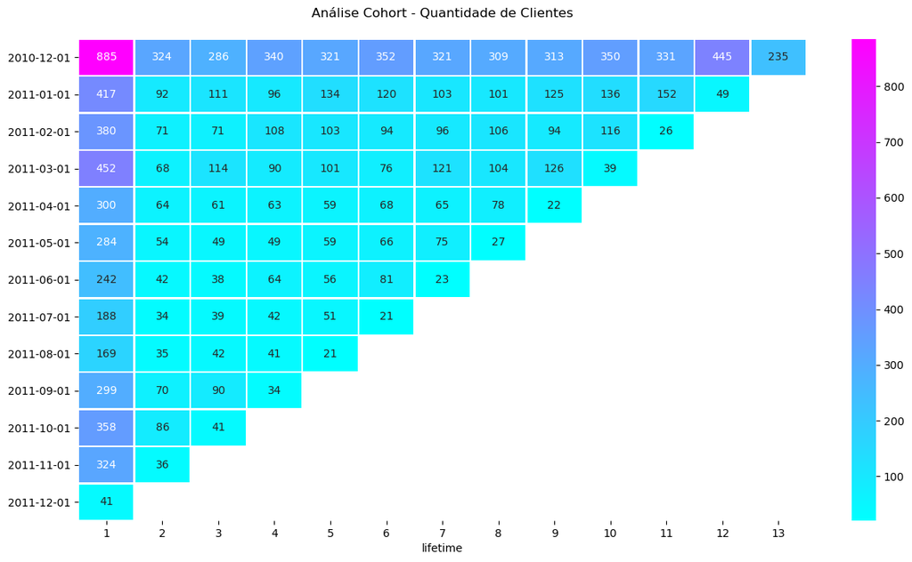

```python
matriz_cohort = cohort.pivot(index='PrimeiroMes',columns='lifetime',values='ClienteID')
matriz_cohort.index = matriz_cohort.index.date
plt.figure(figsize=(15, 8))
plt.style.use('default')
plt.title('Análise Cohort - Quantidade de Clientes', pad=20)
sns.heatmap(data=matriz_cohort,annot = True,fmt = '.0f',cmap="cool", linecolor='white', linewidth=1)
plt.show()
```

Esta matriz diz respeito à **quantidade de clientes**.

Uma forma mais eficaz de visualizar a retenção é aplicando a **taxa**: dividindo a quantidade de clientes pelo total daquele coorte.

## Análise de coorte - Retenção

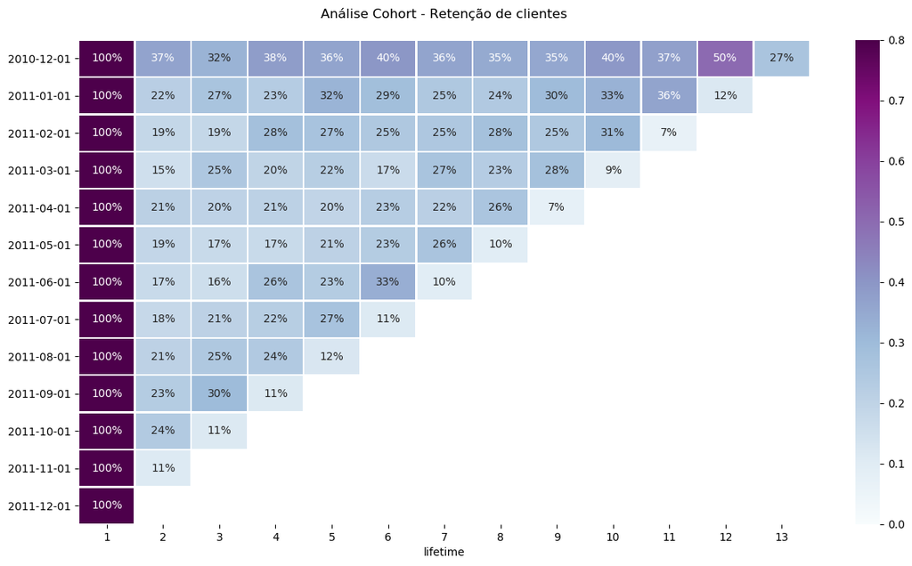

```python
totaldeclientes = matriz_cohort.iloc[:,0]
retencao = matriz_cohort.divide(totaldeclientes,axis=0)
retencao.round(3) * 100
plt.figure(figsize=(15, 8))
plt.style.use('default')
plt.title('Análise Cohort - Retenção de clientes', pad=20)
sns.heatmap(data=retencao,annot = True,fmt = '.0%',cmap="BuPu", linecolor='white', linewidth=1, vmin=0, vmax=0.8)
plt.show()
```

**Referências**

[Conjunto de dados no repositório da UCI](https://archive.ics.uci.edu/ml/datasets/online+retail)

[Cohort Analysis & Customer Segmentation with RFM](https://www.kaggle.com/mahmoudelfahl/cohort-analysis-customer-segmentation-with-rfm)